# Indicadores de victimización y percepción de inseguridad

ENAPRES, sintaxis SPSS, estimación de indicadores y análisis comparado

Autor/a

Noam López Villanes

Fecha de publicación

16 de mayo de 2026

## 1 Objetivo de la sesión

En esta sesión trabajaremos con indicadores de victimización, percepción de inseguridad y confianza en la Policía Nacional del Perú a partir de ENAPRES. La sesión tiene dos propósitos: reconstruir la serie 2010-2025 desde microdatos y usar esos indicadores para hacer ejercicios de estadística inferencial.

1. Importar bases con codificación correcta.
2. Reconocer indicadores, años y ámbitos de análisis.
3. Comparar tendencias nacionales y diferencias departamentales.
4. Replicar indicadores desde microdatos de seguridad ciudadana.
5. Revisar filtros, factores de expansión y cambios de cuestionario entre años.
6. Relacionar victimización, percepción y confianza en la PNP.
7. Estimar porcentajes ponderados, intervalos de confianza y asociaciones bivariadas.

## 2 Preparación

Si ejecutas este documento por partes, corre primero los chunks de **Instalar paquetes**, **Activar paquetes** y **Ubicar archivos**. Los tres están ocultos en el redenrizado final, pero esos bloques crean los paquetes, funciones y rutas que usan los demás chunks.

## 3 Importar resultados calculados

¿Qué resultados generó nuestro script a partir de los microdatos?

```r
archivo_micro_nacional <- file.path(
  ruta_resultados,
  "enapres_indicadores_nacionales.csv"
)
archivo_micro_region <- file.path(
  ruta_resultados,
  "enapres_indicadores_region.csv"
)
archivo_micro_individual <- file.path(
  ruta_resultados,
  "enapres_microdatos_indicadores.csv"
)

if (
  !file.exists(archivo_micro_nacional) ||
    !file.exists(archivo_micro_region) ||
    !file.exists(archivo_micro_individual)
) {
  source(file.path(ruta_scripts, "procesar_enapres_mod600.R"))
}

micro_nacional <- read_csv(archivo_micro_nacional, show_col_types = FALSE)
micro_region <- read_csv(archivo_micro_region, show_col_types = FALSE)
micro_individual <- read_csv(
  archivo_micro_individual,
  show_col_types = FALSE
) |>
  mutate(
    sexo = factor(sexo, levels = c("Hombre", "Mujer")),
    grupo_edad = factor(
      grupo_edad,
      levels = c("15 a 24", "25 a 39", "40 a 59", "60 a más")
    )
  )

nombres_indicadores <- c(
  victimizacion = "Victimización",
  percepcion_12m = "Percepción próximos 12 meses",
  percepcion_noche = "Percepción al caminar de noche",
  percepcion_dia = "Percepción al caminar de día",
  confianza_pnp = "Confianza en la PNP",
  robo_intento_dinero_cartera_celular = "Robo o intento de robo",
  estafa = "Estafa"
)

indicadores_nacionales_largo <- micro_nacional |>
  pivot_longer(
    cols = any_of(names(nombres_indicadores)),
    names_to = "indicador",
    values_to = "valor"
  ) |>
  mutate(
    indicador = recode(indicador, !!!nombres_indicadores)
  )

indicadores_region_largo <- micro_region |>
  pivot_longer(
    cols = any_of(names(nombres_indicadores)),
    names_to = "indicador",
    values_to = "valor"
  ) |>
  mutate(
    indicador = recode(indicador, !!!nombres_indicadores)
  )

glimpse(micro_nacional)
```

```
Rows: 16
Columns: 10
$ anio                                <dbl> 2010, 2011, 2012, 2013, 2014, 2015…
$ personas_victimizacion              <dbl> 89142, 85985, 84752, 84218, 71776,…
$ personas_percepcion                 <dbl> 89142, 85985, 84752, 84218, 71776,…
$ victimizacion                       <dbl> 14.24518, 20.84287, 18.40321, 35.8…
$ percepcion_12m                      <dbl> 79.23058, 86.16190, 84.87617, 87.5…
$ percepcion_noche                    <dbl> NA, NA, NA, 58.13288, 58.44583, 58…
$ percepcion_dia                      <dbl> NA, NA, NA, NA, NA, NA, NA, NA, NA…
$ confianza_pnp                       <dbl> 37.88785, 27.58795, 24.32636, 20.4…
$ robo_intento_dinero_cartera_celular <dbl> 21.35755, 23.41902, 21.26860, 21.9…
$ estafa                              <dbl> 4.783240, 1.291354, 11.050427, 11.…
```

```r
glimpse(micro_individual)
```

```
Rows: 1,174,508
Columns: 24
$ archivo                             <chr> "ENAPRES 2010.sav", "ENAPRES 2010.…
$ version_cuestionario                <chr> "cuestionario_2019_2023_cap600", "…
$ anio                                <dbl> 2010, 2010, 2010, 2010, 2010, 2010…
$ mes                                 <chr> "05", "05", "05", "05", "05", "05"…
$ ccdd                                <chr> "24", "24", "24", "24", "24", "24"…
$ ccpp                                <chr> "01", "01", "01", "01", "01", "01"…
$ departamento                        <chr> NA, NA, NA, NA, NA, NA, NA, NA, NA…
$ region_final                        <chr> NA, NA, NA, NA, NA, NA, NA, NA, NA…
$ conglomerado                        <chr> "00036", "00036", "00036", "00036"…
$ vivienda                            <chr> "001", "001", "001", "002", "002",…
$ hogar                               <dbl> 1, 1, 1, 1, 1, 1, 1, 1, 1, 1, 1, 1…
$ estrato                             <dbl> NA, NA, NA, NA, NA, NA, NA, NA, NA…
$ sexo                                <fct> Hombre, Mujer, Mujer, Hombre, Muje…
$ edad                                <dbl> 38, 30, 15, 49, 45, 14, 45, 41, 20…
$ grupo_edad                          <fct> 25 a 39, 25 a 39, 15 a 24, 40 a 59…
$ peso_victimizacion                  <dbl> 53.38186, 53.38186, 53.38186, 53.3…
$ peso_percepcion                     <dbl> 53.38186, 53.38186, 53.38186, 53.3…
$ victimizacion                       <dbl> 0, 0, 0, 0, 0, NA, 0, 0, 0, 0, 1, …
$ percepcion_12m                      <dbl> 0, 0, 0, 0, 0, NA, 1, 0, 0, 0, 0, …
$ percepcion_noche                    <dbl> NA, NA, NA, NA, NA, NA, NA, NA, NA…
$ percepcion_dia                      <dbl> NA, NA, NA, NA, NA, NA, NA, NA, NA…
$ confianza_pnp                       <dbl> NA, NA, NA, NA, NA, NA, NA, NA, NA…
$ robo_intento_dinero_cartera_celular <dbl> 0, 0, 0, 0, 0, NA, 0, 0, 0, 0, 1, …
$ estafa                              <dbl> 0, 0, 0, 0, 0, NA, 0, 0, 0, 0, 0, …
```

El archivo individual conserva una fila por persona y agrega los indicadores calculados. Los archivos nacional y regional son resúmenes ponderados, es decir, usan el factor de expansión para estimar porcentajes poblacionales.

¿Hay valores perdidos o años incompletos que debamos tener presentes antes de graficar?

```r
micro_nacional |>
  summarise(
    filas = n(),
    columnas = ncol(micro_nacional),
    anio_minimo = min(anio, na.rm = TRUE),
    anio_maximo = max(anio, na.rm = TRUE)
  )
```

| filas | columnas | anio_minimo | anio_maximo |
| --- | --- | --- | --- |
| 16 | 10 | 2010 | 2025 |

```r
indicadores_nacionales_largo |>
  group_by(indicador) |>
  summarise(
    primer_anio = min(anio[!is.na(valor)], na.rm = TRUE),
    ultimo_anio = max(anio[!is.na(valor)], na.rm = TRUE),
    anios_con_dato = sum(!is.na(valor)),
    .groups = "drop"
  )
```

| indicador | primer_anio | ultimo_anio | anios_con_dato |
| --- | --- | --- | --- |
| Confianza en la PNP | 2010 | 2025 | 16 |
| Estafa | 2010 | 2025 | 16 |
| Percepción al caminar de día | 2022 | 2024 | 3 |
| Percepción al caminar de noche | 2013 | 2025 | 13 |
| Percepción próximos 12 meses | 2010 | 2025 | 16 |
| Robo o intento de robo | 2010 | 2025 | 16 |
| Victimización | 2010 | 2025 | 16 |

La cobertura temporal no es idéntica para todos los indicadores. Por eso conviene mirar primero qué años están disponibles antes de comparar tendencias.

## 4 Tendencias nacionales

¿Cómo evolucionan los principales indicadores nacionales de seguridad que calculamos desde microdatos?

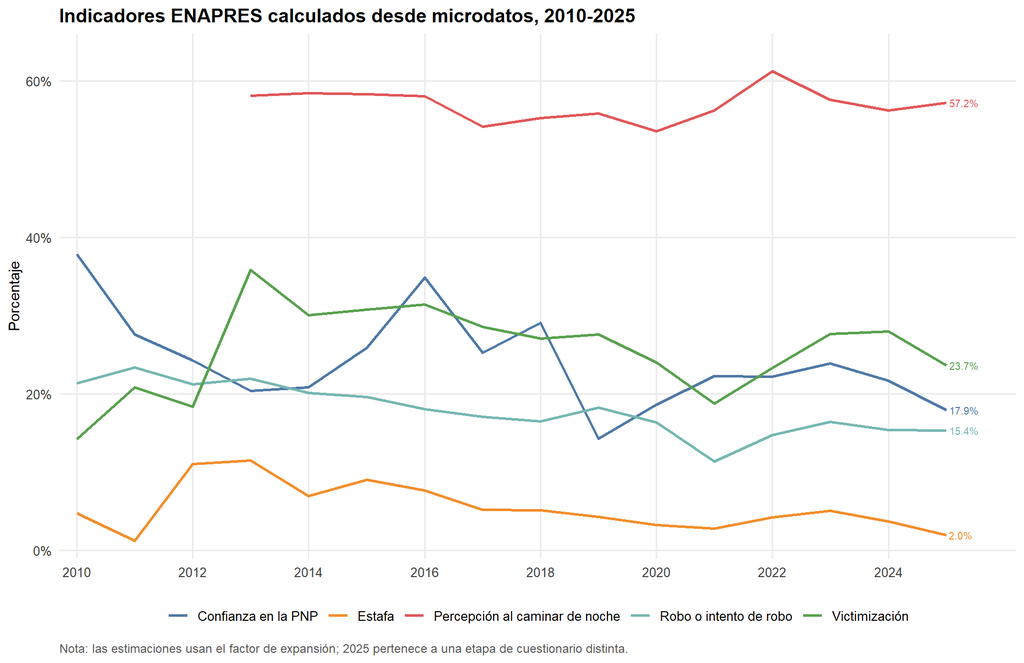

```r
indicadores_nacionales_grafico <- indicadores_nacionales_largo |>
  filter(!is.na(valor)) |>
  filter(
    indicador %in%
      c(
        "Victimización",
        "Percepción al caminar de noche",
        "Confianza en la PNP",
        "Robo o intento de robo",
        "Estafa"
      )
  )

etiquetas_nacionales <- indicadores_nacionales_grafico |>
  group_by(indicador) |>
  filter(anio == max(anio, na.rm = TRUE)) |>
  ungroup()

indicadores_nacionales_grafico |>
  ggplot(aes(
    x = anio,
    y = valor / 100,
    color = indicador
  )) +
  geom_line(linewidth = 1.05) +
  geom_text(
    data = etiquetas_nacionales,
    aes(label = percent(valor / 100, accuracy = 0.1)),
    hjust = -0.12,
    size = 2.7,
    show.legend = FALSE
  ) +
  scale_y_continuous(
    labels = percent_format(),
    expand = expansion(mult = c(0.04, 0.08))
  ) +
  scale_x_continuous(
    breaks = seq(min(micro_nacional$anio), max(micro_nacional$anio), by = 2),
    expand = expansion(mult = c(0.02, 0.08))
  ) +
  scale_color_paletteer_d("ggthemes::Tableau_10") +
  labs(
    title = "Indicadores ENAPRES calculados desde microdatos, 2010-2025",
    x = NULL,
    y = "Porcentaje",
    color = NULL,
    caption = "Nota: las estimaciones usan el factor de expansión; 2025 pertenece a una etapa de cuestionario distinta."
  ) +
  tema_sesion() +
  theme(
    plot.caption = element_text(hjust = 0, color = "grey35", size = 9),
    plot.title = element_text(size = 14),
    legend.box = "vertical"
  )
```

La comparación temporal permite ver que victimización y percepción no necesariamente se mueven igual. Como las estimaciones salen de microdatos, el punto central de la clase es entender qué estamos estimando y cómo el factor de expansión convierte respuestas muestrales en porcentajes poblacionales.

¿Qué indicador cambió más entre el primer y el último año disponible?

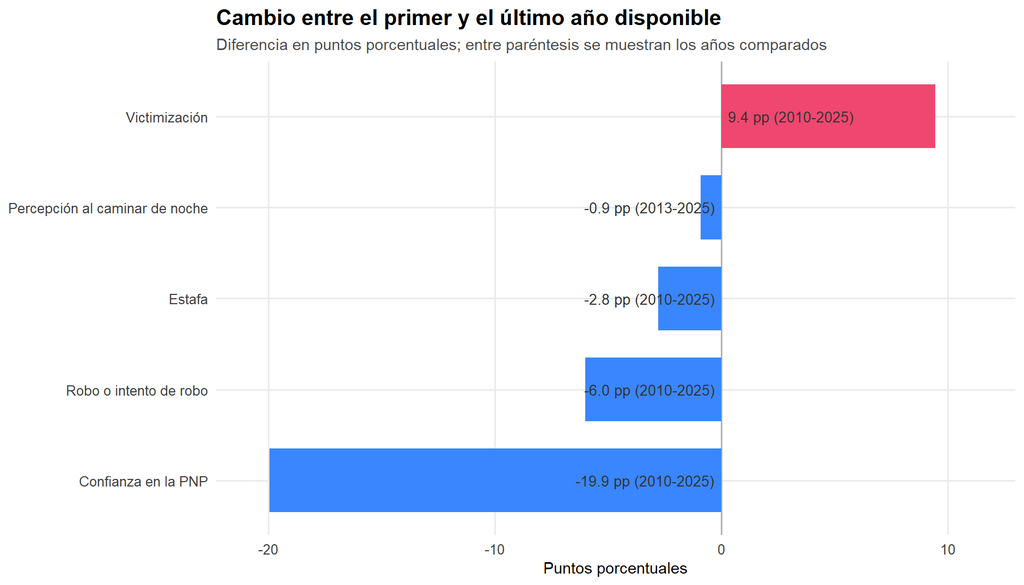

```r
cambios_nacionales <- indicadores_nacionales_grafico |>
  filter(!is.na(valor)) |>
  arrange(indicador, anio) |>
  group_by(indicador) |>
  summarise(
    primer_anio = first(anio),
    ultimo_anio = last(anio),
    primer_valor = first(valor),
    ultimo_valor = last(valor),
    cambio_puntos = ultimo_valor - primer_valor,
    comparacion = str_c(primer_anio, "-", ultimo_anio),
    etiqueta = str_c(
      number(cambio_puntos, accuracy = 0.1),
      " pp (",
      comparacion,
      ")"
    ),
    .groups = "drop"
  )

cambios_nacionales |>
  ggplot(aes(
    x = reorder(indicador, cambio_puntos),
    y = cambio_puntos
  )) +
  geom_hline(yintercept = 0, color = "grey70") +
  geom_col(aes(fill = cambio_puntos > 0), width = 0.7, show.legend = FALSE) +
  geom_text(
    aes(
      y = if_else(cambio_puntos < 0, -0.12, 0.12),
      label = etiqueta,
      hjust = if_else(cambio_puntos < 0, 1.03, -0.03)
    ),
    size = 3.5,
    color = "grey20"
  ) +
  coord_flip() +
  scale_fill_manual(values = c("#3a86ff", "#ef476f")) +
  scale_y_continuous(expand = expansion(mult = c(0.08, 0.12))) +
  labs(
    title = "Cambio entre el primer y el último año disponible",
    subtitle = "Diferencia en puntos porcentuales; entre paréntesis se muestran los años comparados",
    x = NULL,
    y = "Puntos porcentuales"
  ) +
  tema_sesion() +
  theme(plot.title = element_text(size = 15))
```

Esta forma de resumir el cambio ayuda a no quedarnos solo con la última foto. Un indicador puede estar alto, pero haber caído; otro puede estar bajo, pero creciendo.

## 5 Diferencias territoriales

¿Qué departamentos muestran mayores niveles de victimización en el último año disponible?

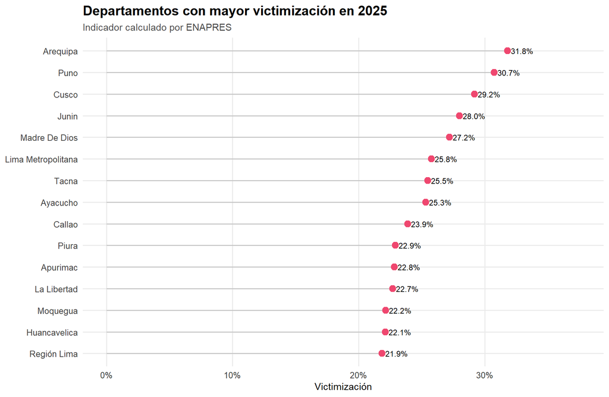

```r
ultimo_anio <- max(micro_region$anio, na.rm = TRUE)

ranking_departamental <- indicadores_region_largo |>
  filter(
    anio == ultimo_anio,
    indicador == "Victimización"
  ) |>
  arrange(desc(valor))

ranking_departamental |>
  slice_max(valor, n = 15) |>
  ggplot(aes(x = valor / 100, y = reorder(region_final, valor))) +
  geom_segment(
    aes(x = 0, xend = valor / 100, yend = region_final),
    color = "grey78"
  ) +
  geom_point(size = 3.2, color = "#ef476f") +
  geom_text(
    aes(label = percent(valor / 100, accuracy = 0.1)),
    hjust = -0.15,
    size = 3.2
  ) +
  scale_x_continuous(
    labels = percent_format(),
    limits = c(0, max(ranking_departamental$valor) / 100 * 1.18)
  ) +
  labs(
    title = glue("Departamentos con mayor victimización en {ultimo_anio}"),
    subtitle = "Indicador calculado por ENAPRES",
    x = "Victimización",
    y = NULL
  ) +
  tema_sesion()
```

El ranking sirve para ubicar casos extremos, pero no debe confundirse con una explicación. Para explicar diferencias territoriales se necesita relacionar estos indicadores con otras características sociales, institucionales o urbanas.

¿Cómo se distribuye la victimización departamental a lo largo del tiempo?

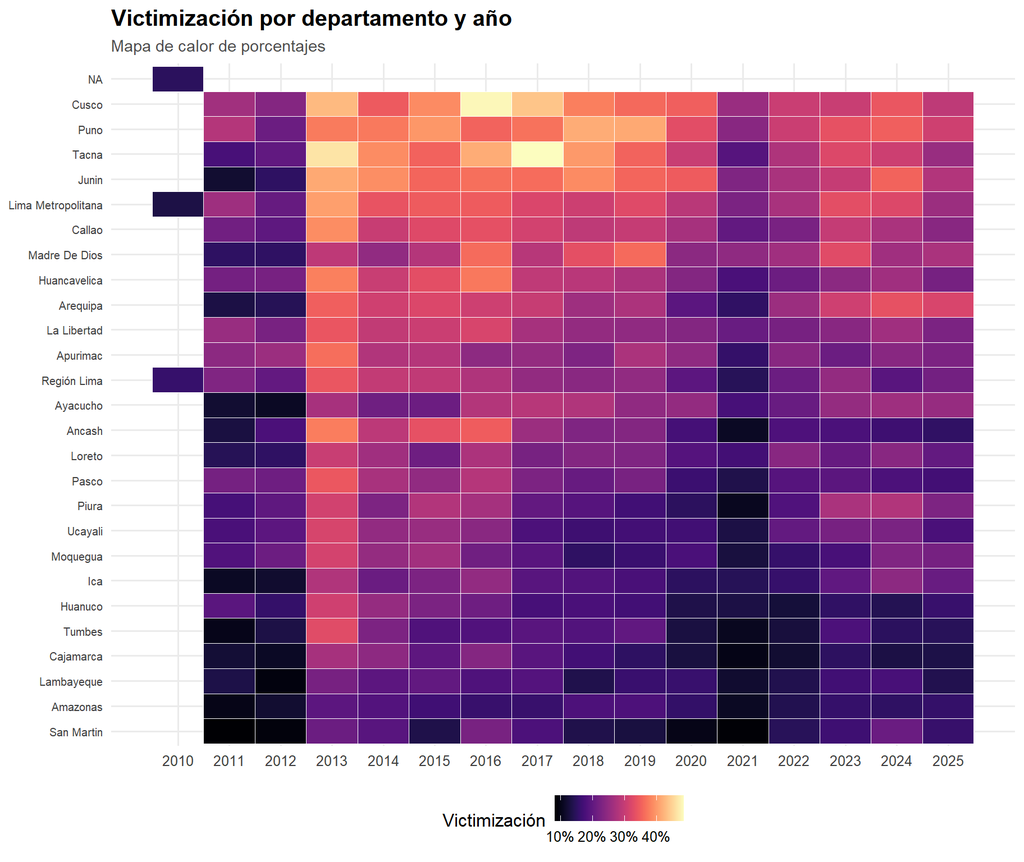

```r
victimizacion_departamental <- indicadores_region_largo |>
  filter(
    indicador == "Victimización"
  )

victimizacion_departamental |>
  group_by(region_final) |>
  mutate(promedio_departamento = mean(valor, na.rm = TRUE)) |>
  ungroup() |>
  ggplot(aes(
    x = anio,
    y = reorder(region_final, promedio_departamento),
    fill = valor / 100
  )) +
  geom_tile(color = "white", linewidth = 0.2) +
  scale_fill_paletteer_c("viridis::magma", labels = percent_format()) +
  scale_x_continuous(breaks = sort(unique(victimizacion_departamental$anio))) +
  labs(
    title = "Victimización por departamento y año",
    subtitle = "Mapa de calor de porcentajes",
    x = NULL,
    y = NULL,
    fill = "Victimización"
  ) +
  tema_sesion() +
  theme(axis.text.y = element_text(size = 7.5))
```

El mapa de calor permite detectar persistencias y cambios simultáneamente. Es útil para preguntar si un departamento aparece sistemáticamente alto o si tuvo un aumento puntual.

## 6 Relacionar indicadores

¿Los lugares con más victimización también tienen mayor percepción al caminar de noche?

```r
# HTML: imagen dinámica
# PDF: imagen estática
indicadores_ultimo_anio <- indicadores_region_largo |>
  filter(
    anio == ultimo_anio,
    indicador %in%
      c(
        "Victimización",
        "Percepción al caminar de noche",
        "Confianza en la PNP"
      )
  ) |>
  select(region_final, indicador, valor) |>
  pivot_wider(names_from = indicador, values_from = valor) |>
  clean_names()

grafico_victimizacion_percepcion <- indicadores_ultimo_anio |>
  ggplot(aes(
    x = victimizacion / 100,
    y = percepcion_al_caminar_de_noche / 100,
    text = glue(
      "{region_final}<br>",
      "Victimización: {percent(victimizacion / 100, accuracy = 0.1)}<br>",
      "Percepción al caminar de noche: {percent(percepcion_al_caminar_de_noche / 100, accuracy = 0.1)}<br>",
      "Confianza en la PNP: {percent(confianza_en_la_pnp / 100, accuracy = 0.1)}"
    )
  )) +
  geom_point(aes(color = confianza_en_la_pnp / 100), size = 3.2, alpha = 0.85) +
  geom_smooth(method = "lm", se = FALSE, color = "grey35", linewidth = 0.8) +
  scale_x_continuous(labels = percent_format()) +
  scale_y_continuous(labels = percent_format()) +
  scale_color_paletteer_c("viridis::plasma", labels = percent_format()) +
  labs(
    title = glue(
      "Victimización y percepción al caminar de noche en {ultimo_anio}"
    ),
    subtitle = "Cada punto representa un departamento",
    x = "Victimización",
    y = "Percepción al caminar de noche",
    color = "Confianza en la PNP"
  ) +
  tema_sesion()

ggplotly(grafico_victimizacion_percepcion, tooltip = "text")
```

[interactive chart not shown]

La nube de puntos permite discutir si la percepción de inseguridad acompaña a la victimización o si hay departamentos donde ambas variables se separan. Esa separación puede convertirse en una pregunta de investigación.

¿Dónde es más grande la brecha entre percepción de inseguridad y victimización?

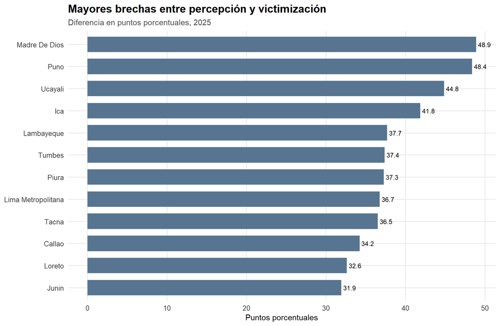

```r
brechas_departamentales <- indicadores_ultimo_anio |>
  mutate(
    brecha_percepcion_victimizacion = percepcion_al_caminar_de_noche -
      victimizacion
  ) |>
  arrange(desc(brecha_percepcion_victimizacion))

brechas_departamentales |>
  slice_max(brecha_percepcion_victimizacion, n = 12) |>
  ggplot(aes(
    x = brecha_percepcion_victimizacion,
    y = reorder(region_final, brecha_percepcion_victimizacion)
  )) +
  geom_col(fill = "#577590", width = 0.7) +
  geom_text(
    aes(label = number(brecha_percepcion_victimizacion, accuracy = 0.1)),
    hjust = -0.15,
    size = 3.2
  ) +
  labs(
    title = "Mayores brechas entre percepción y victimización",
    subtitle = glue("Diferencia en puntos porcentuales, {ultimo_anio}"),
    x = "Puntos porcentuales",
    y = NULL
  ) +
  tema_sesion()
```

La brecha resume una idea sustantiva: no toda inseguridad percibida proviene directamente de la victimización reciente. Medios, experiencias cercanas, deterioro urbano y confianza institucional pueden intervenir.

## 7 Cómo se calculan los indicadores

Antes de interpretar los resultados conviene abrir la caja negra: estos indicadores no están en la base como una sola variable lista para usar, sino que se construyen combinando filtros, factores de expansión y varias preguntas del cuestionario.

El flujo de trabajo tiene dos piezas. El script `procesar_enapres_mod600.R` lee los microdatos, calcula los indicadores y exporta archivos `.csv` y `.sav`. Este QMD usa los `.csv` para explicar, graficar y trabajar la inferencia; los `.sav` quedan disponibles para abrirlos y analizarlos directamente en SPSS.

La idea es la misma en SPSS y en R: primero se define el universo de análisis, luego se identifican las preguntas que forman cada indicador, después se crean variables binarias con valores `0` y `1`, y finalmente se aplica el factor de expansión. La diferencia es que R permite convertir esa lógica en una función reutilizable para varios años.

La regla de lectura no es idéntica para todos los años. Entre 2010 y 2023 se trabaja con la estructura histórica del módulo de seguridad ciudadana; 2024 requiere un mapeo especial dentro del capítulo 600; y 2025 cambia con más fuerza porque pasa al capítulo 400. Por eso la serie se puede reconstruir completa, pero las comparaciones deben marcar esos cortes.

| Paso del cálculo | Variables y etiquetas que se revisan | En SPSS | En R |
| --- | --- | --- | --- |
| Definir el universo de análisis: personas urbanas de 15 años a más, con entrevista válida y residencia habitual. | `AREA` área, `RESFIN` resultado final, `P208_A` edad, `P204/P205/P206` residencia habitual. | `COMPUTE filtro_enapres = (...)` y luego `IF` o `SELECT IF`, según si se quiere conservar o filtrar la base. | `mutate(filtro_general = AREA == 1 & RESFIN < 3 & P208_A >= 15 & ...)`. |
| Excluir omisiones del módulo o capítulo correspondiente. | `P600_C` en la serie histórica, `P600B_C/P600C_C` en 2024, `P400_C/P400A_C` en 2025. | `IF (P600_C <> 99) filtro_modulo600 = 1`. | `mutate(valido_victimizacion = as.numeric(P600_C) != 99)`, adaptado por año. |
| Aplicar el factor de expansión correcto para estimar porcentajes poblacionales. | `FACTOR`, `FACTOR600`, `FACTORANUAL`; para algunos años se revisan factores específicos o calibrados. | `WEIGHT BY FACTOR`. | `weighted.mean(indicador, w = peso) * 100`. |
| Calcular victimización: si la persona reporta al menos un hecho delictivo. | `P601_*` en la serie histórica, `P615_*` en 2024, `P424_*` en 2025. Etiqueta: victimización. | `COMPUTE victimizacion = ANY(1, P601_1, P601_2, ...)`. | `row_any_equal(data, vars_victimizacion, 1)`. |
| Calcular percepción de inseguridad en los próximos 12 meses. | `P611_1:P611_14` en la serie histórica; `P601_*` en 2024; `P401/P402_*` en 2025. | `COMPUTE percepcion_12m = ANY(1, P611_1 TO P611_14)`. | `row_any_equal(data, vars_percepcion_12m, 1)`. |
| Calcular percepción de inseguridad al caminar de noche. | `P611A`, `P611B` o `P611B_1`, según año; `P604` en 2024; `P405` en 2025. | `IF (ANY(P611B_1, 1, 2)) percepcion_noche = 1`. | `case_when(!is.na(P611B_1) ~ indicador_en(P611B_1, c(1, 2)), ...)`. |
| Calcular confianza en la PNP y delitos específicos usados en clase. | `P608_1`, `P616A_1` o `P409_1` para confianza; `P601_6A/P601_6B`, `P615_9/P615_10`, `P424_9/P424_10` para robo o intento; `P601_13`, `P615_21`, `P424_21` para estafa. | `COMPUTE confianza_pnp = ANY(P608_1, 3, 4)` y reglas similares para cada delito. | `case_when()` para escoger variables según año y `indicador_en()` para recodificar respuestas. |
| Guardar una base con indicadores calculados para seguir analizando. | Variables nuevas: `victimizacion`, `percepcion_12m`, `percepcion_noche`, `confianza_pnp`, `estafa`, entre otras. | `SAVE OUTFILE = '.../enapres_2023_indicadores_desde_spss.sav'`. | `write_csv()` y `write_sav()` hacia la carpeta `resultados`. |

¿Cómo se ejecuta el script que procesa los `.sav` de seguridad ciudadana?

```r
source(file.path(ruta_scripts, "procesar_enapres_mod600.R"))
```

El script exporta tres archivos en `resultados`: una base individual con indicadores, una tabla nacional y una tabla regional. Si luego se agregan nuevas bases de seguridad ciudadana, el mismo flujo puede volver a ejecutarse.

Además, la carpeta `scripts` incluye una sintaxis SPSS para 2023. Esa sintaxis calcula los indicadores dentro de una base ENAPRES específica, conserva las filas originales, agrega variables nuevas y guarda una copia `.sav` con los indicadores.

¿Qué resultados nacionales se obtienen al replicar los indicadores desde microdatos para toda la serie disponible?

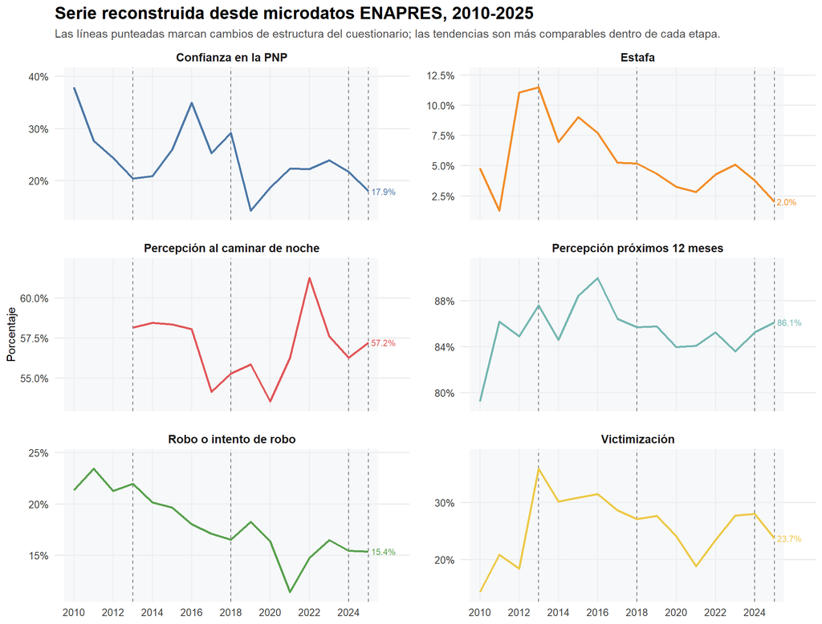

```r
archivo_micro_nacional <- file.path(
  ruta_resultados,
  "enapres_indicadores_nacionales.csv"
)

if (!file.exists(archivo_micro_nacional)) {
  stop(
    "Ejecuta primero el script procesar_enapres_mod600.R para crear los indicadores desde microdatos."
  )
}

micro_nacional <- read_csv(archivo_micro_nacional, show_col_types = FALSE)

micro_largo <- micro_nacional |>
  pivot_longer(
    cols = c(
      victimizacion,
      percepcion_12m,
      percepcion_noche,
      confianza_pnp,
      robo_intento_dinero_cartera_celular,
      estafa
    ),
    names_to = "indicador",
    values_to = "valor"
  ) |>
  mutate(
    indicador = recode(
      indicador,
      victimizacion = "Victimización",
      percepcion_12m = "Percepción próximos 12 meses",
      percepcion_noche = "Percepción al caminar de noche",
      confianza_pnp = "Confianza en la PNP",
      robo_intento_dinero_cartera_celular = "Robo o intento de robo",
      estafa = "Estafa"
    )
  ) |>
  filter(!is.na(valor))

etiquetas_micro_final <- micro_largo |>
  group_by(indicador) |>
  filter(anio == max(anio, na.rm = TRUE)) |>
  ungroup()

micro_largo |>
  ggplot(aes(
    x = anio,
    y = valor / 100,
    color = indicador,
    group = indicador
  )) +
  geom_rect(
    data = etapas_enapres,
    aes(xmin = xmin, xmax = xmax, ymin = -Inf, ymax = Inf),
    inherit.aes = FALSE,
    fill = "#f1f3f5",
    alpha = 0.55
  ) +
  geom_vline(
    data = cortes_enapres,
    aes(xintercept = anio),
    inherit.aes = FALSE,
    linetype = "dashed",
    color = "grey45",
    linewidth = 0.4
  ) +
  geom_line(linewidth = 0.95, na.rm = TRUE) +
  geom_text(
    data = etiquetas_micro_final,
    aes(label = percent(valor / 100, accuracy = 0.1)),
    hjust = -0.12,
    size = 2.9,
    show.legend = FALSE,
    na.rm = TRUE
  ) +
  facet_wrap(~indicador, ncol = 2, scales = "free_y") +
  scale_y_continuous(
    labels = percent_format(),
    expand = expansion(mult = c(0.08, 0.16))
  ) +
  scale_x_continuous(
    breaks = seq(2010, 2025, by = 2),
    minor_breaks = NULL,
    expand = expansion(mult = c(0.03, 0.10))
  ) +
  scale_color_paletteer_d("ggthemes::Tableau_10", guide = "none") +
  labs(
    title = "Serie reconstruida desde microdatos ENAPRES, 2010-2025",
    subtitle = "Las líneas punteadas marcan cambios de estructura del cuestionario; las tendencias son más comparables dentro de cada etapa.",
    x = NULL,
    y = "Porcentaje"
  ) +
  tema_sesion() +
  theme(
    strip.text = element_text(face = "bold", size = 11),
    plot.title = element_text(size = 16),
    plot.subtitle = element_text(size = 11),
    panel.spacing = unit(1.1, "lines")
  )
```

La réplica desde microdatos permite mirar 2010-2025, pero no todos los tramos tienen la misma comparabilidad. El salto 2012-2013 y los rediseños de 2024-2025 deben leerse como cambios metodológicos además de posibles cambios reales en victimización, percepción o confianza.

¿Cómo debemos leer los cortes de la serie?

```r
etapas_enapres |>
  transmute(
    etapa,
    lectura = c(
      "Útil para recuperar la trayectoria inicial, pero algunas variables todavía no están disponibles con la misma definición posterior.",
      "Tramo donde se consolida la medición reciente de varios indicadores; permite comparar tendencias con cautela.",
      "Tramo más estable para ejercicios de comparación temporal y territorial.",
      "Año de rediseño del capítulo 600; conviene validar cada indicador antes de unirlo mecánicamente con años previos.",
      "Año con cambio al capítulo 400; debe tratarse como una nueva etapa de medición."
    )
  )
```

| etapa | lectura |
| --- | --- |
| 2010-2012: estructura inicial | Útil para recuperar la trayectoria inicial, pero algunas variables todavía no están disponibles con la misma definición posterior. |
| 2013-2017: transición y estabilización | Tramo donde se consolida la medición reciente de varios indicadores; permite comparar tendencias con cautela. |
| 2018-2023: serie comparable reciente | Tramo más estable para ejercicios de comparación temporal y territorial. |
| 2024: rediseño del capítulo 600 | Año de rediseño del capítulo 600; conviene validar cada indicador antes de unirlo mecánicamente con años previos. |
| 2025: cambio al capítulo 400 | Año con cambio al capítulo 400; debe tratarse como una nueva etapa de medición. |

## 8 Estimación e inferencia

Hasta aquí hemos descrito tendencias. Ahora damos un paso inferencial: usamos los microdatos y el factor de expansión para estimar porcentajes poblacionales, construir intervalos de confianza y explorar asociaciones entre variables.

Para esta parte trabajaremos con `2024`. La razón es práctica: es un año reciente y todavía pertenece al capítulo 600. Aun así, 2024 ya no usa exactamente los mismos nombres de variables de la serie histórica: para victimización se usan preguntas `P615_*`, para percepción de los próximos 12 meses se usan preguntas `P601_*`, para percepción al caminar de noche se usa `P604`, y para algunos indicadores se aplican factores específicos del capítulo como `FACTOR_CAP600B`. El año 2025 puede analizarse también, pero debe leerse como una etapa distinta porque cambia al capítulo 400.

```r
options(survey.lonely.psu = "adjust")

anio_inferencia <- 2024

base_inferencia <- micro_individual |>
  filter(anio == anio_inferencia) |>
  mutate(
    victimizacion = as.numeric(victimizacion),
    percepcion_12m = as.numeric(percepcion_12m),
    percepcion_noche = as.numeric(percepcion_noche),
    confianza_pnp = as.numeric(confianza_pnp),
    victimizacion_cat = factor(
      victimizacion,
      levels = c(0, 1),
      labels = c("No", "Sí")
    )
  )

diseno_victimizacion <- svydesign(
  ids = ~1,
  weights = ~peso_victimizacion,
  data = base_inferencia |>
    filter(!is.na(victimizacion), !is.na(peso_victimizacion))
)

diseno_percepcion <- svydesign(
  ids = ~1,
  weights = ~peso_percepcion,
  data = base_inferencia |>
    filter(!is.na(percepcion_12m), !is.na(peso_percepcion))
)
```

Estos diseños usan el factor de expansión. Para mantener la explicación en clase manejable, los intervalos se presentan como aproximaciones ponderadas; si se incorporan estratos y conglomerados completos, el cálculo de errores estándar puede afinarse.

¿Cuánto estimamos para los principales indicadores en 2024?

```r
extraer_estimacion <- function(objeto, indicador) {
  tibble(
    indicador = indicador,
    estimacion = as.numeric(coef(objeto)),
    se = as.numeric(SE(objeto)),
    conf_bajo = confint(objeto)[1, 1],
    conf_alto = confint(objeto)[1, 2]
  )
}

estimaciones_inferencia <- bind_rows(
  extraer_estimacion(
    svymean(~victimizacion, diseno_victimizacion, na.rm = TRUE),
    "Victimización"
  ),
  extraer_estimacion(
    svymean(~percepcion_12m, diseno_percepcion, na.rm = TRUE),
    "Percepción próximos 12 meses"
  ),
  extraer_estimacion(
    svymean(~percepcion_noche, diseno_percepcion, na.rm = TRUE),
    "Percepción al caminar de noche"
  ),
  extraer_estimacion(
    svymean(~confianza_pnp, diseno_percepcion, na.rm = TRUE),
    "Confianza en la PNP"
  )
) |>
  mutate(across(c(estimacion, conf_bajo, conf_alto), ~ .x * 100))

estimaciones_inferencia
```

| indicador | estimacion | se | conf_bajo | conf_alto |
| --- | --- | --- | --- | --- |
| Victimización | 28.00679 | 0.002995065 | 27.41977 | 28.59381 |
| Percepción próximos 12 meses | 85.22653 | 0.003618139 | 84.51739 | 85.93567 |
| Percepción al caminar de noche | 56.26700 | 0.005348530 | 55.21871 | 57.31529 |
| Confianza en la PNP | 21.69582 | 0.005663228 | 20.58585 | 22.80580 |

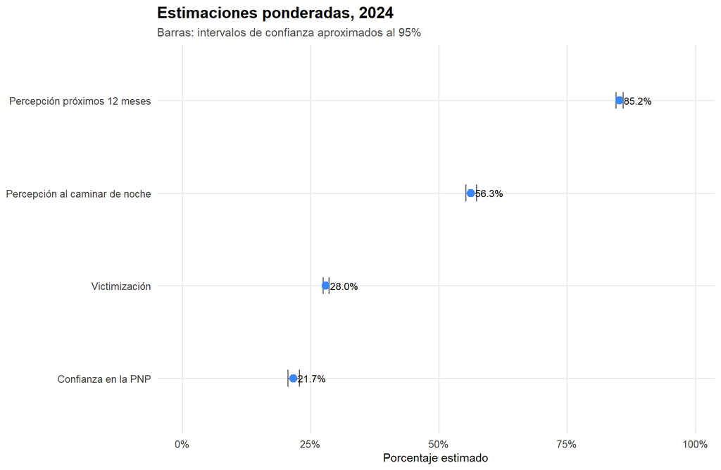

```r
estimaciones_inferencia |>
  ggplot(aes(x = estimacion / 100, y = reorder(indicador, estimacion))) +
  geom_errorbar(
    aes(xmin = conf_bajo / 100, xmax = conf_alto / 100),
    width = 0.18,
    color = "grey45"
  ) +
  geom_point(size = 3.2, color = "#3a86ff") +
  geom_text(
    aes(label = percent(estimacion / 100, accuracy = 0.1)),
    hjust = -0.15,
    size = 3.3
  ) +
  scale_x_continuous(
    labels = percent_format(),
    limits = c(0, max(estimaciones_inferencia$conf_alto) / 100 * 1.15)
  ) +
  labs(
    title = glue("Estimaciones ponderadas, {anio_inferencia}"),
    subtitle = "Barras: intervalos de confianza aproximados al 95%",
    x = "Porcentaje estimado",
    y = NULL
  ) +
  tema_sesion()
```

El intervalo de confianza recuerda que no observamos a toda la población: estimamos un valor poblacional a partir de una muestra. El factor de expansión indica cuántas personas representa cada observación.

¿La victimización estimada cambia según sexo?

```r
victimizacion_sexo <- svyby(
  ~victimizacion,
  ~sexo,
  diseno_victimizacion,
  svymean,
  vartype = "ci",
  na.rm = TRUE
) |>
  as_tibble() |>
  mutate(across(c(victimizacion, ci_l, ci_u), ~ .x * 100))

victimizacion_sexo
```

| sexo | victimizacion | ci_l | ci_u |
| --- | --- | --- | --- |
| Hombre | 30.38490 | 29.49396 | 31.27585 |
| Mujer | 25.82946 | 25.06027 | 26.59865 |

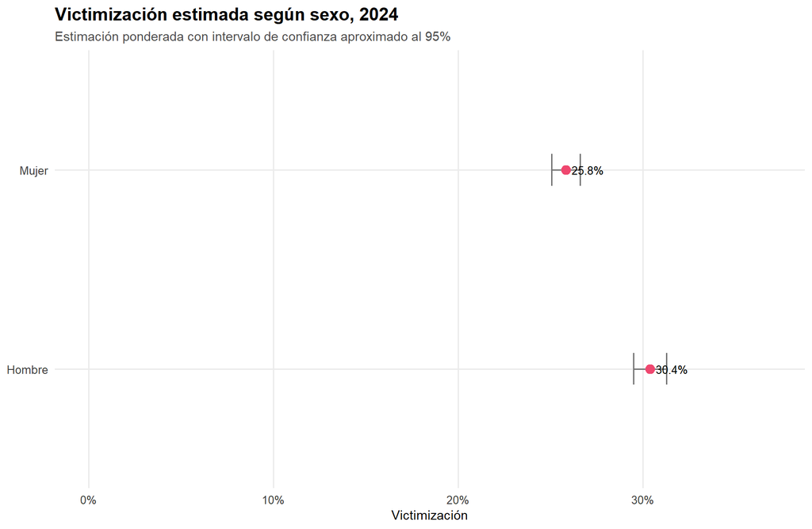

```r
victimizacion_sexo |>
  ggplot(aes(x = victimizacion / 100, y = sexo)) +
  geom_errorbar(
    aes(xmin = ci_l / 100, xmax = ci_u / 100),
    width = 0.16,
    color = "grey45"
  ) +
  geom_point(size = 3.4, color = "#ef476f") +
  geom_text(
    aes(label = percent(victimizacion / 100, accuracy = 0.1)),
    hjust = -0.18,
    size = 3.4
  ) +
  scale_x_continuous(
    labels = percent_format(),
    limits = c(0, max(victimizacion_sexo$ci_u) / 100 * 1.18)
  ) +
  labs(
    title = glue("Victimización estimada según sexo, {anio_inferencia}"),
    subtitle = "Estimación ponderada con intervalo de confianza aproximado al 95%",
    x = "Victimización",
    y = NULL
  ) +
  tema_sesion()
```

El cruce por sexo permite pasar de una descripción general a una pregunta bivariada: si los intervalos se superponen mucho, la diferencia observada debe leerse con cautela.

¿La victimización estimada cambia según grupo de edad?

```r
victimizacion_edad <- svyby(
  ~victimizacion,
  ~grupo_edad,
  diseno_victimizacion,
  svymean,
  vartype = "ci",
  na.rm = TRUE
) |>
  as_tibble() |>
  filter(!is.na(grupo_edad)) |>
  mutate(across(c(victimizacion, ci_l, ci_u), ~ .x * 100))

victimizacion_edad
```

| grupo_edad | victimizacion | ci_l | ci_u |
| --- | --- | --- | --- |
| 15 a 24 | 32.68799 | 31.40287 | 33.97312 |
| 25 a 39 | 34.41014 | 33.20991 | 35.61038 |
| 40 a 59 | 28.16899 | 27.11186 | 29.22612 |
| 60 a más | 16.29566 | 15.18686 | 17.40447 |

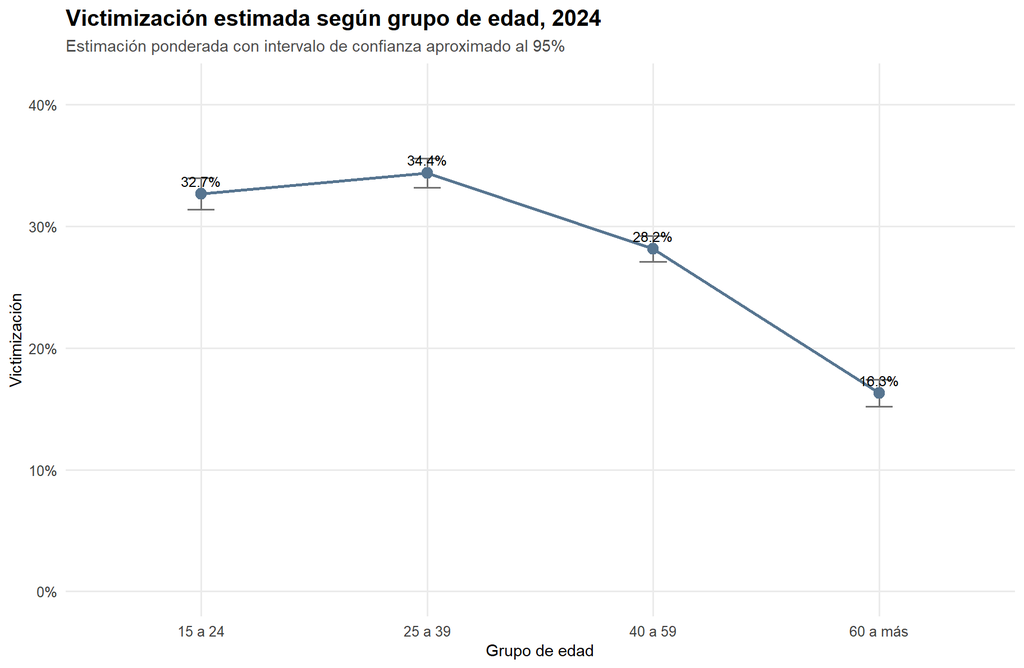

```r
victimizacion_edad |>
  ggplot(aes(x = grupo_edad, y = victimizacion / 100, group = 1)) +
  geom_errorbar(
    aes(ymin = ci_l / 100, ymax = ci_u / 100),
    width = 0.12,
    color = "grey45"
  ) +
  geom_line(color = "#577590", linewidth = 0.9) +
  geom_point(size = 3.2, color = "#577590") +
  geom_text(
    aes(label = percent(victimizacion / 100, accuracy = 0.1)),
    vjust = -0.7,
    size = 3.3
  ) +
  scale_y_continuous(
    labels = percent_format(),
    limits = c(0, max(victimizacion_edad$ci_u) / 100 * 1.16)
  ) +
  labs(
    title = glue(
      "Victimización estimada según grupo de edad, {anio_inferencia}"
    ),
    subtitle = "Estimación ponderada con intervalo de confianza aproximado al 95%",
    x = "Grupo de edad",
    y = "Victimización"
  ) +
  tema_sesion()
```

La edad introduce una variable categórica ordenada. Aquí la pregunta no es solo quién tiene el porcentaje más alto, sino si la diferencia entre grupos parece suficientemente clara para sostener una interpretación.

¿La asociación entre sexo y victimización es estadísticamente distinguible de cero?

```r
prueba_sexo_victimizacion <- svychisq(
  ~ sexo + victimizacion_cat,
  diseno_victimizacion
)

prueba_sexo_victimizacion
```

```
    Pearson's X^2: Rao & Scott adjustment

data:  svychisq(~sexo + victimizacion_cat, diseno_victimizacion)
F = 57.947, ndf = 1, ddf = 62348, p-value = 2.731e-14
```

El resultado de la prueba de Rao-Scott sugiere que existe una asociación estadísticamente significativa entre sexo y victimización. En otras palabras, la proporción de personas victimizadas no parece distribuirse igual entre hombres y mujeres. Esta asociación no implica causalidad; solo indica que ambas variables no se comportan como independientes en la muestra ponderada.

¿Qué pasa si modelamos la probabilidad de victimización con sexo y edad?

```r
modelo_victimizacion <- svyglm(
  victimizacion ~ sexo + grupo_edad,
  design = diseno_victimizacion,
  family = quasibinomial()
)

tabla_modelo <- summary(modelo_victimizacion)$coefficients |>
  as.data.frame() |>
  rownames_to_column("termino") |>
  as_tibble() |>
  transmute(
    termino,
    estimacion_logit = Estimate,
    error_estandar = `Std. Error`,
    estadistico_t = `t value`,
    p_valor = `Pr(>|t|)`,
    razon_de_odds = exp(Estimate)
  )

tabla_modelo
```

| termino | estimacion_logit | error_estandar | estadistico_t | p_valor | razon_de_odds |
| --- | --- | --- | --- | --- | --- |
| (Intercept) | -0.62064282 | 0.03311523 | -18.741916 | 3.699755e-78 | 0.5375987 |
| sexoMujer | -0.21577507 | 0.03007479 | -7.174617 | 7.331401e-13 | 0.8059166 |
| grupo_edad25 a 39 | 0.08648717 | 0.04043395 | 2.138974 | 3.244166e-02 | 1.0903374 |
| grupo_edad40 a 59 | -0.20201037 | 0.04004774 | -5.044239 | 4.566058e-07 | 0.8170865 |
| grupo_edad60 a más | -0.90379657 | 0.05111196 | -17.682682 | 8.448732e-70 | 0.4050290 |

El modelo logístico es una forma compacta de estudiar asociaciones multivariadas. La razón de odds mayor que 1 indica mayor probabilidad relativa frente al grupo de referencia; menor que 1 indica menor probabilidad relativa.

## 9 Ejercicios para seguir practicando

1. Repite la comparación entre victimización y confianza en la PNP para otro año.
2. Calcula la variación departamental entre 2019 y 2024 para un indicador.
3. Identifica tres departamentos con alta percepción y baja victimización.
4. Revisa la sintaxis SPSS y agrega un indicador adicional al script de R.
5. Cuando descargues nuevas bases de seguridad ciudadana, colócalas en `datos`, ejecuta el script y revisa si aparecen nuevas variables o cambios de nombres.

Estos ejercicios pueden apoyarse en el Posit Assistant de RStudio para revisar errores, pedir explicaciones de funciones y proponer mejoras al código.